# Un_Data_Exploration_R

```r
library(tidyverse)
library(dplyr)
#install.packages("ggplot2")
#install.packages("readr")
library(ggplot2)
```

## Introduction to the Tidyverse: An Exploration of UN Data

In this project, you’ll be redoing the UN Data project using the tidyverse libraries. You have been provided three csv files, gdp_per_capita.csv, life_expectancy.csv, and continents.csv.

Create a new R Notebook to complete this exercise.

1. Using the `read_csv()` function, read the GDP dataset into your notebook as a tibble called `gdp_df`. After reading it in, inspect the first 10 rows and then inspect the last 10 rows.

```r
gdp <- read.csv('../data/gdp_per_capita.csv')
life_exp <- read.csv('../data/life_expectancy.csv', skip = 4)
```

2. Drop the ‘Value Footnotes’ column, and rename the remaining columns to ‘Country’, ‘Year’, and ‘GDP_Per_Capita’.

```r
gdp <- gdp %>% select(-'Value.Footnotes')
gdp
```

| Country.or.Area | Year | Value |
| --- | --- | --- |
| Afghanistan | 2021 | 1517.0163 |
| Afghanistan | 2020 | 1968.3410 |
| Afghanistan | 2019 | 2079.9219 |
| Afghanistan | 2018 | 2060.6990 |
| Afghanistan | 2017 | 2096.0931 |
| Afghanistan | 2016 | 2101.4222 |
| Afghanistan | 2015 | 2108.7142 |
| Afghanistan | 2014 | 2144.4496 |
| Afghanistan | 2013 | 2165.3409 |
| Afghanistan | 2012 | 2122.8308 |

[output cut: 990 more lines]

3. Which years are represented in this dataset? How many observations are there per year? Make a plot to view the number of observations per year.

```r
year_count <- gdp %>%
  group_by(Year) %>%
  summarize(count = n()) %>%
  arrange(desc(count))
year_count
```

| Year | count |
| --- | --- |
| 2013 | 242 |
| 2014 | 242 |
| 2015 | 242 |
| 2016 | 242 |
| 2017 | 242 |
| 2018 | 242 |
| 2019 | 242 |
| 2020 | 242 |
| 2021 | 241 |
| 2011 | 240 |

[output cut: 23 more lines]

4. How many countries are represented in this dataset? Which countries have the fewest observations?

```r
country_count <- gdp %>%
  group_by(Country.or.Area) %>%
  summarize(count = n()) %>%
  arrange(desc(count))
tail(country_count)
```

| Country.or.Area | count |
| --- | --- |
| Cayman Islands | 16 |
| Kosovo | 15 |
| Sint Maarten (Dutch part) | 14 |
| Turks and Caicos Islands | 12 |
| Djibouti | 10 |
| Somalia | 10 |

5. Create a new tibble by subsetting `gdp_df` to just the year 2021. Call this new tibble `gdp_2021`.

```r
gdp_2021 <- gdp %>%
  filter(Year == 2021)
gdp_2021
```

| Country.or.Area | Year | Value |
| --- | --- | --- |
| Afghanistan | 2021 | 1517.0163 |
| Africa Eastern and Southern | 2021 | 3519.1748 |
| Africa Western and Central | 2021 | 4014.6080 |
| Albania | 2021 | 14595.9444 |
| Algeria | 2021 | 11029.1388 |
| Angola | 2021 | 5911.8357 |
| Antigua and Barbuda | 2021 | 19899.8824 |
| Arab World | 2021 | 13745.2062 |
| Argentina | 2021 | 21527.1961 |
| Armenia | 2021 | 14193.1168 |

[output cut: 231 more lines]

6. Use `summary()` to find the summary statistics for GDP per capita in 2021.

```r
summary(gdp_2021['Value'])
```

```
     Value
 Min.   :   714.1
 1st Qu.:  5044.2
 Median : 13754.8
 Mean   : 20711.6
 3rd Qu.: 30974.4
 Max.   :115683.5
```

7. Create a histogram of GDP Per Capita numbers for 2021 (you may wish to adjust the number of bins for your histogram).

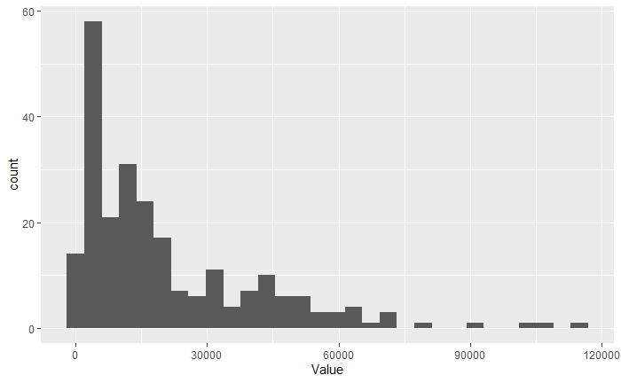

```r
ggplot(data = gdp_2021, aes(x = Value)) +
  geom_histogram()
```

8. Find the top 5 counties and bottom 5 countries by GDP per capita in 2021.

```r
gdp_2021_top_five <- gdp_2021 %>%
  arrange(desc(Value)) %>%
  head(5)

gdp_2021_top_five
```

|  | Country.or.Area | Year | Value |
| --- | --- | --- | --- |
| 1 | Luxembourg | 2021 | 115683.49 |
| 2 | Singapore | 2021 | 107741.12 |
| 3 | Ireland | 2021 | 102785.49 |
| 4 | Qatar | 2021 | 92862.57 |
| 5 | Bermuda | 2021 | 78570.49 |

```r
gdp_2021_bottom_five <- gdp_2021 %>%
  arrange(Value) %>%
  head(5)

gdp_2021_bottom_five
```

|  | Country.or.Area | Year | Value |
| --- | --- | --- | --- |
| 1 | Burundi | 2021 | 714.0667 |
| 2 | Central African Republic | 2021 | 837.5047 |
| 3 | Dem. Rep. Congo | 2021 | 1073.6433 |
| 4 | Somalia | 2021 | 1136.7360 |
| 5 | Niger | 2021 | 1186.5768 |

9. Now, return to the full dataset, `gdp_df`. Pivot the data for 1990 and 2021 (using `pivot_wider()` function) so that each row corresponds to a country, each column corresponds to a year, and the values in the table give the GDP_Per_Capita amount. Drop any rows that are missing values for either 1990 or 2021. Save the result to a tibble named `gdp_pivoted`.

```r
gdp_pivot <- gdp %>%
  pivot_wider(names_from = Year, values_from = Value)
gdp_pivot
```

| Country.or.Area | 2021 | 2020 | 2019 | 2018 | 2017 | 2016 | 2015 | 2014 | 2013 | 2012 | 2011 | 2010 | 2009 | 2008 | 2007 | 2006 | 2005 | 2004 | 2003 | 2002 | 2022 | 2001 | 2000 | 1999 | 1998 | 1997 | 1996 | 1995 | 1994 | … |
| --- | --- | --- | --- | --- | --- | --- | --- | --- | --- | --- | --- | --- | --- | --- | --- | --- | --- | --- | --- | --- | --- | --- | --- | --- | --- | --- | --- | --- | --- | --- |
| Afghanistan | 1517.0163 | 1968.3410 | 2079.9219 | 2060.6990 | 2096.0931 | 2101.4222 | 2108.7142 | 2144.4496 | 2165.3409 | 2122.8308 | 1961.0963 | 2026.1638 | 1823.7426 | 1556.8445 | 1528.3446 | 1366.9931 | 1352.3206 | 1260.0606 | 1292.3334 | 1280.4632 | NA | NA | NA | NA | NA | NA | NA | NA | NA | … |
| Africa Eastern and Southern | 3519.1748 | 3455.0231 | 3648.2203 | 3661.3606 | 3659.0591 | 3654.5788 | 3658.5336 | 3642.8754 | 3593.2991 | 3543.8249 | 3558.3785 | 3513.3159 | 3431.1780 | 3501.8381 | 3440.8412 | 3310.5150 | 3185.3941 | 3075.5462 | 2985.9186 | 2966.0398 | 3553.9134 | 2928.0629 | 2897.1408 | 2873.5537 | 2867.9602 | 2886.5662 | 2838.6920 | 2764.3050 | 2715.1311 | … |
| Africa Western and Central | 4014.6080 | 3957.9338 | 4093.4429 | 4064.0799 | 4051.2712 | 4055.9433 | 4148.5473 | 4146.9946 | 4026.2319 | 3901.7248 | 3811.7604 | 3737.5067 | 3599.3515 | 3491.5474 | 3379.5521 | 3296.9528 | 3217.7024 | 3128.2967 | 2982.7083 | 2907.9834 | 4063.8577 | 2734.2576 | 2671.5992 | 2649.5559 | 2676.5298 | 2654.3849 | 2612.1948 | 2561.6654 | 2575.0642 | … |
| Albania | 14595.9444 | 13278.3698 | 13653.1822 | 13317.1193 | 12770.9919 | 12291.8421 | 11878.4376 | 11586.8174 | 11361.2525 | 11227.9504 | 11052.7779 | 10749.4664 | 10313.9017 | 9912.1485 | 9150.1168 | 8568.5497 | 8040.0814 | 7580.1281 | 7153.9954 | 6753.8812 | 15501.6629 | 6441.4407 | 5892.5822 | 5474.8499 | 4819.0678 | 4400.3128 | 4908.9324 | 4471.6017 | 3921.6150 | … |
| Algeria | 11029.1388 | 10844.7708 | 11627.2799 | 11725.8777 | 11809.4830 | 11888.3230 | 11751.6341 | 11561.2598 | 11360.6376 | 11270.7010 | 11113.9689 | 11007.7466 | 10824.5764 | 10847.1766 | 10775.5321 | 10592.2471 | 10566.3728 | 10114.7256 | 9835.1617 | 9299.6821 | 11187.3823 | 8926.1101 | 8786.1903 | 8584.0715 | 8435.0357 | 8147.8782 | 8195.8605 | 8013.1234 | 7869.2703 | … |
| Angola | 5911.8357 | 6029.6919 | 6602.2692 | 6878.5900 | 7216.0614 | 7487.9251 | 7966.8856 | 8183.1646 | 8099.6788 | 8011.0501 | 7663.2861 | 7689.8207 | 7646.1444 | 7866.1843 | 7340.3889 | 6677.0197 | 6204.5888 | 5589.2379 | 5217.3905 | 5241.8206 | 5906.1157 | 4768.0089 | 4728.3744 | 4739.5096 | 4790.4186 | 4728.2923 | 4557.1478 | 4149.4457 | 3728.8862 | … |
| Antigua and Barbuda | 19899.8824 | 18787.5644 | 22908.6393 | 22072.5557 | 20777.5595 | 20267.5488 | 19344.6656 | 18779.1391 | 18243.4826 | 18526.0537 | 18116.8565 | 18701.7502 | 20571.5327 | 23726.9483 | 24087.6839 | 22340.3857 | 20076.0738 | 19077.0635 | 18236.9351 | 17388.2275 | 21457.9379 | 17432.7007 | 18545.5826 | 17754.2217 | 17414.1312 | 16943.5872 | 16391.4203 | 15690.6447 | 16730.2139 | … |
| Arab World | 13745.2062 | 13466.4898 | 14358.1691 | 14420.0122 | 14332.3535 | 14388.8593 | 14148.5282 | 13872.2273 | 13836.2235 | 13788.1720 | 13329.3847 | 13162.0296 | 12892.3313 | 13164.4449 | 12806.2082 | 12577.7850 | 12190.3986 | 11830.8722 | 11148.0202 | 10857.6120 | 14324.3966 | 11031.1691 | 11082.7423 | 10654.9442 | 10685.0582 | 10393.1723 | 10193.8458 | 9975.5305 | 9954.2245 | … |
| Argentina | 21527.1961 | 19685.2159 | 22071.7481 | 22747.2417 | 23597.1178 | 23189.5274 | 23933.8866 | 23550.0991 | 24424.1364 | 24118.8675 | 24647.6293 | 23521.2702 | 21413.2831 | 22992.3902 | 22316.2555 | 20679.2431 | 19338.1462 | 17950.1513 | 16631.5740 | 15439.7446 | 22447.0885 | 17514.5041 | 18524.8096 | 18884.9431 | 19773.1764 | 19261.8986 | 18031.5482 | 17303.9238 | 18046.8929 | … |
| Armenia | 14193.1168 | 13357.6971 | 14317.5529 | 13231.4311 | 12509.6396 | 11580.3836 | 11506.0390 | 11105.5325 | 10677.3037 | 10289.9756 | 9551.1581 | 9068.7877 | 8819.6775 | 10201.5595 | 9476.4715 | 8273.7857 | 7259.2039 | 6334.8562 | 5698.7785 | 4965.2244 | 16041.8297 | 4346.9075 | 3921.8575 | 3660.0341 | 3505.3684 | 3236.0605 | 3105.9528 | 2912.7811 | 2683.6375 | … |

[output cut: 232 more lines]

```r
gdp_pivot <- gdp_pivot %>%
  filter(!is.na(`1990`) & !is.na(`2021`))

gdp_pivot
```

| Country.or.Area | 2021 | 2020 | 2019 | 2018 | 2017 | 2016 | 2015 | 2014 | 2013 | 2012 | 2011 | 2010 | 2009 | 2008 | 2007 | 2006 | 2005 | 2004 | 2003 | 2002 | 2022 | 2001 | 2000 | 1999 | 1998 | 1997 | 1996 | 1995 | 1994 | … |
| --- | --- | --- | --- | --- | --- | --- | --- | --- | --- | --- | --- | --- | --- | --- | --- | --- | --- | --- | --- | --- | --- | --- | --- | --- | --- | --- | --- | --- | --- | --- |
| Africa Eastern and Southern | 3519.1748 | 3455.0231 | 3648.2203 | 3661.3606 | 3659.0591 | 3654.5788 | 3658.5336 | 3642.8754 | 3593.2991 | 3543.8249 | 3558.3785 | 3513.3159 | 3431.1780 | 3501.8381 | 3440.8412 | 3310.5150 | 3185.3941 | 3075.5462 | 2985.9186 | 2966.0398 | 3553.9134 | 2928.0629 | 2897.1408 | 2873.5537 | 2867.9602 | 2886.5662 | 2838.6920 | 2764.3050 | 2715.1311 | … |
| Africa Western and Central | 4014.6080 | 3957.9338 | 4093.4429 | 4064.0799 | 4051.2712 | 4055.9433 | 4148.5473 | 4146.9946 | 4026.2319 | 3901.7248 | 3811.7604 | 3737.5067 | 3599.3515 | 3491.5474 | 3379.5521 | 3296.9528 | 3217.7024 | 3128.2967 | 2982.7083 | 2907.9834 | 4063.8577 | 2734.2576 | 2671.5992 | 2649.5559 | 2676.5298 | 2654.3849 | 2612.1948 | 2561.6654 | 2575.0642 | … |
| Albania | 14595.9444 | 13278.3698 | 13653.1822 | 13317.1193 | 12770.9919 | 12291.8421 | 11878.4376 | 11586.8174 | 11361.2525 | 11227.9504 | 11052.7779 | 10749.4664 | 10313.9017 | 9912.1485 | 9150.1168 | 8568.5497 | 8040.0814 | 7580.1281 | 7153.9954 | 6753.8812 | 15501.6629 | 6441.4407 | 5892.5822 | 5474.8499 | 4819.0678 | 4400.3128 | 4908.9324 | 4471.6017 | 3921.6150 | … |
| Algeria | 11029.1388 | 10844.7708 | 11627.2799 | 11725.8777 | 11809.4830 | 11888.3230 | 11751.6341 | 11561.2598 | 11360.6376 | 11270.7010 | 11113.9689 | 11007.7466 | 10824.5764 | 10847.1766 | 10775.5321 | 10592.2471 | 10566.3728 | 10114.7256 | 9835.1617 | 9299.6821 | 11187.3823 | 8926.1101 | 8786.1903 | 8584.0715 | 8435.0357 | 8147.8782 | 8195.8605 | 8013.1234 | 7869.2703 | … |
| Angola | 5911.8357 | 6029.6919 | 6602.2692 | 6878.5900 | 7216.0614 | 7487.9251 | 7966.8856 | 8183.1646 | 8099.6788 | 8011.0501 | 7663.2861 | 7689.8207 | 7646.1444 | 7866.1843 | 7340.3889 | 6677.0197 | 6204.5888 | 5589.2379 | 5217.3905 | 5241.8206 | 5906.1157 | 4768.0089 | 4728.3744 | 4739.5096 | 4790.4186 | 4728.2923 | 4557.1478 | 4149.4457 | 3728.8862 | … |
| Antigua and Barbuda | 19899.8824 | 18787.5644 | 22908.6393 | 22072.5557 | 20777.5595 | 20267.5488 | 19344.6656 | 18779.1391 | 18243.4826 | 18526.0537 | 18116.8565 | 18701.7502 | 20571.5327 | 23726.9483 | 24087.6839 | 22340.3857 | 20076.0738 | 19077.0635 | 18236.9351 | 17388.2275 | 21457.9379 | 17432.7007 | 18545.5826 | 17754.2217 | 17414.1312 | 16943.5872 | 16391.4203 | 15690.6447 | 16730.2139 | … |
| Arab World | 13745.2062 | 13466.4898 | 14358.1691 | 14420.0122 | 14332.3535 | 14388.8593 | 14148.5282 | 13872.2273 | 13836.2235 | 13788.1720 | 13329.3847 | 13162.0296 | 12892.3313 | 13164.4449 | 12806.2082 | 12577.7850 | 12190.3986 | 11830.8722 | 11148.0202 | 10857.6120 | 14324.3966 | 11031.1691 | 11082.7423 | 10654.9442 | 10685.0582 | 10393.1723 | 10193.8458 | 9975.5305 | 9954.2245 | … |
| Argentina | 21527.1961 | 19685.2159 | 22071.7481 | 22747.2417 | 23597.1178 | 23189.5274 | 23933.8866 | 23550.0991 | 24424.1364 | 24118.8675 | 24647.6293 | 23521.2702 | 21413.2831 | 22992.3902 | 22316.2555 | 20679.2431 | 19338.1462 | 17950.1513 | 16631.5740 | 15439.7446 | 22447.0885 | 17514.5041 | 18524.8096 | 18884.9431 | 19773.1764 | 19261.8986 | 18031.5482 | 17303.9238 | 18046.8929 | … |
| Armenia | 14193.1168 | 13357.6971 | 14317.5529 | 13231.4311 | 12509.6396 | 11580.3836 | 11506.0390 | 11105.5325 | 10677.3037 | 10289.9756 | 9551.1581 | 9068.7877 | 8819.6775 | 10201.5595 | 9476.4715 | 8273.7857 | 7259.2039 | 6334.8562 | 5698.7785 | 4965.2244 | 16041.8297 | 4346.9075 | 3921.8575 | 3660.0341 | 3505.3684 | 3236.0605 | 3105.9528 | 2912.7811 | 2683.6375 | … |
| Aruba | 38866.3335 | 33155.2432 | 40780.5165 | 40706.7492 | 38865.1882 | 37043.6982 | 36490.5245 | 35467.2358 | 35720.6981 | 33815.1093 | 34446.8569 | 33639.3962 | 34978.0091 | 40096.7815 | 39866.7156 | 39146.9093 | 39166.1338 | 39713.8467 | 37353.5587 | 37309.7879 | NA | 38123.3424 | 37241.0305 | 35495.2486 | 36105.2602 | 36479.9418 | 35125.9271 | 35780.7228 | 35984.8294 | … |

[output cut: 196 more lines]

10. Create a new column in `gdp_pivoted` named `Percent_Change`. This column should contain the percent change in GDP_Per_Capita from 1990 to 2021. Hint: Percent change is calculated as 100*(New Value - Old Value) / Old Value.

```r
gdp_pivot_new <- gdp_pivot %>%
  mutate(Percent_Change = (`2021` - `1990`) / `1990` * 100)

gdp_pivot_new
```

| Country.or.Area | 2021 | 2020 | 2019 | 2018 | 2017 | 2016 | 2015 | 2014 | 2013 | 2012 | 2011 | 2010 | 2009 | 2008 | 2007 | 2006 | 2005 | 2004 | 2003 | 2002 | 2022 | 2001 | 2000 | 1999 | 1998 | 1997 | 1996 | 1995 | 1994 | … |
| --- | --- | --- | --- | --- | --- | --- | --- | --- | --- | --- | --- | --- | --- | --- | --- | --- | --- | --- | --- | --- | --- | --- | --- | --- | --- | --- | --- | --- | --- | --- |
| Africa Eastern and Southern | 3519.1748 | 3455.0231 | 3648.2203 | 3661.3606 | 3659.0591 | 3654.5788 | 3658.5336 | 3642.8754 | 3593.2991 | 3543.8249 | 3558.3785 | 3513.3159 | 3431.1780 | 3501.8381 | 3440.8412 | 3310.5150 | 3185.3941 | 3075.5462 | 2985.9186 | 2966.0398 | 3553.9134 | 2928.0629 | 2897.1408 | 2873.5537 | 2867.9602 | 2886.5662 | 2838.6920 | 2764.3050 | 2715.1311 | … |
| Africa Western and Central | 4014.6080 | 3957.9338 | 4093.4429 | 4064.0799 | 4051.2712 | 4055.9433 | 4148.5473 | 4146.9946 | 4026.2319 | 3901.7248 | 3811.7604 | 3737.5067 | 3599.3515 | 3491.5474 | 3379.5521 | 3296.9528 | 3217.7024 | 3128.2967 | 2982.7083 | 2907.9834 | 4063.8577 | 2734.2576 | 2671.5992 | 2649.5559 | 2676.5298 | 2654.3849 | 2612.1948 | 2561.6654 | 2575.0642 | … |
| Albania | 14595.9444 | 13278.3698 | 13653.1822 | 13317.1193 | 12770.9919 | 12291.8421 | 11878.4376 | 11586.8174 | 11361.2525 | 11227.9504 | 11052.7779 | 10749.4664 | 10313.9017 | 9912.1485 | 9150.1168 | 8568.5497 | 8040.0814 | 7580.1281 | 7153.9954 | 6753.8812 | 15501.6629 | 6441.4407 | 5892.5822 | 5474.8499 | 4819.0678 | 4400.3128 | 4908.9324 | 4471.6017 | 3921.6150 | … |
| Algeria | 11029.1388 | 10844.7708 | 11627.2799 | 11725.8777 | 11809.4830 | 11888.3230 | 11751.6341 | 11561.2598 | 11360.6376 | 11270.7010 | 11113.9689 | 11007.7466 | 10824.5764 | 10847.1766 | 10775.5321 | 10592.2471 | 10566.3728 | 10114.7256 | 9835.1617 | 9299.6821 | 11187.3823 | 8926.1101 | 8786.1903 | 8584.0715 | 8435.0357 | 8147.8782 | 8195.8605 | 8013.1234 | 7869.2703 | … |
| Angola | 5911.8357 | 6029.6919 | 6602.2692 | 6878.5900 | 7216.0614 | 7487.9251 | 7966.8856 | 8183.1646 | 8099.6788 | 8011.0501 | 7663.2861 | 7689.8207 | 7646.1444 | 7866.1843 | 7340.3889 | 6677.0197 | 6204.5888 | 5589.2379 | 5217.3905 | 5241.8206 | 5906.1157 | 4768.0089 | 4728.3744 | 4739.5096 | 4790.4186 | 4728.2923 | 4557.1478 | 4149.4457 | 3728.8862 | … |
| Antigua and Barbuda | 19899.8824 | 18787.5644 | 22908.6393 | 22072.5557 | 20777.5595 | 20267.5488 | 19344.6656 | 18779.1391 | 18243.4826 | 18526.0537 | 18116.8565 | 18701.7502 | 20571.5327 | 23726.9483 | 24087.6839 | 22340.3857 | 20076.0738 | 19077.0635 | 18236.9351 | 17388.2275 | 21457.9379 | 17432.7007 | 18545.5826 | 17754.2217 | 17414.1312 | 16943.5872 | 16391.4203 | 15690.6447 | 16730.2139 | … |
| Arab World | 13745.2062 | 13466.4898 | 14358.1691 | 14420.0122 | 14332.3535 | 14388.8593 | 14148.5282 | 13872.2273 | 13836.2235 | 13788.1720 | 13329.3847 | 13162.0296 | 12892.3313 | 13164.4449 | 12806.2082 | 12577.7850 | 12190.3986 | 11830.8722 | 11148.0202 | 10857.6120 | 14324.3966 | 11031.1691 | 11082.7423 | 10654.9442 | 10685.0582 | 10393.1723 | 10193.8458 | 9975.5305 | 9954.2245 | … |
| Argentina | 21527.1961 | 19685.2159 | 22071.7481 | 22747.2417 | 23597.1178 | 23189.5274 | 23933.8866 | 23550.0991 | 24424.1364 | 24118.8675 | 24647.6293 | 23521.2702 | 21413.2831 | 22992.3902 | 22316.2555 | 20679.2431 | 19338.1462 | 17950.1513 | 16631.5740 | 15439.7446 | 22447.0885 | 17514.5041 | 18524.8096 | 18884.9431 | 19773.1764 | 19261.8986 | 18031.5482 | 17303.9238 | 18046.8929 | … |
| Armenia | 14193.1168 | 13357.6971 | 14317.5529 | 13231.4311 | 12509.6396 | 11580.3836 | 11506.0390 | 11105.5325 | 10677.3037 | 10289.9756 | 9551.1581 | 9068.7877 | 8819.6775 | 10201.5595 | 9476.4715 | 8273.7857 | 7259.2039 | 6334.8562 | 5698.7785 | 4965.2244 | 16041.8297 | 4346.9075 | 3921.8575 | 3660.0341 | 3505.3684 | 3236.0605 | 3105.9528 | 2912.7811 | 2683.6375 | … |
| Aruba | 38866.3335 | 33155.2432 | 40780.5165 | 40706.7492 | 38865.1882 | 37043.6982 | 36490.5245 | 35467.2358 | 35720.6981 | 33815.1093 | 34446.8569 | 33639.3962 | 34978.0091 | 40096.7815 | 39866.7156 | 39146.9093 | 39166.1338 | 39713.8467 | 37353.5587 | 37309.7879 | NA | 38123.3424 | 37241.0305 | 35495.2486 | 36105.2602 | 36479.9418 | 35125.9271 | 35780.7228 | 35984.8294 | … |

[output cut: 196 more lines]

11. How many countries experienced a negative percent change in GDP per capita from 1990 to 2021?

```r
negative_gdp <- gdp_pivot_new %>%
  filter(Percent_Change < 0)

negative_gdp
```

| Country.or.Area | 2021 | 2020 | 2019 | 2018 | 2017 | 2016 | 2015 | 2014 | 2013 | 2012 | 2011 | 2010 | 2009 | 2008 | 2007 | 2006 | 2005 | 2004 | 2003 | 2002 | 2022 | 2001 | 2000 | 1999 | 1998 | 1997 | 1996 | 1995 | 1994 | … |
| --- | --- | --- | --- | --- | --- | --- | --- | --- | --- | --- | --- | --- | --- | --- | --- | --- | --- | --- | --- | --- | --- | --- | --- | --- | --- | --- | --- | --- | --- | --- |
| Barbados | 13754.8024 | 13805.7775 | 15954.8027 | 16003.8574 | 16198.9622 | 16156.5176 | 15789.4512 | 15441.2198 | 15489.7612 | 15755.2670 | 15864.5723 | 16019.5074 | 16462.7067 | 17405.8935 | 17371.0725 | 17081.6328 | 16154.2612 | 15595.8530 | 15436.6024 | 15167.1268 | 15106.7752 | 15109.7633 | 15517.9408 | 14884.6018 | 14864.6661 | 14353.1201 | 13726.0323 | 13225.7544 | 12993.924 | … |
| Brunei | 60127.0237 | 61603.5508 | 61424.3643 | 59650.2315 | 60173.0511 | 59980.9887 | 62170.0870 | 63131.1862 | 65534.6832 | 67792.7546 | 68037.5230 | 66484.2415 | 65753.4057 | 67934.0641 | 70342.4093 | 71352.8858 | 69482.3838 | 70415.4242 | 71331.7527 | 70631.8737 | 58669.9008 | 69338.9207 | 68865.7873 | 68366.6632 | 67770.1725 | 69660.1860 | 72320.9880 | 71966.0974 | 70570.965 | … |
| Burundi | 714.0667 | 711.3553 | 729.6585 | 740.4482 | 750.7876 | 764.3366 | 781.5793 | 831.2948 | 824.6105 | 814.3208 | 807.6650 | 804.3549 | 801.8034 | 812.5922 | 807.4475 | 809.6960 | 796.1087 | 818.7461 | 810.5523 | 846.7473 | 708.1783 | 833.6709 | 837.3484 | 862.0067 | 891.6998 | 867.2843 | 880.3094 | 956.4910 | 1103.167 | … |
| Central African Republic | 837.5047 | 847.7650 | 861.7668 | 854.6475 | 839.6000 | 818.3960 | 795.0370 | 765.2596 | 764.0515 | 1208.5158 | 1160.4147 | 1130.8957 | 1103.4638 | 1038.3353 | 1038.7501 | 1011.7775 | 985.3248 | 998.6891 | 962.8648 | 1042.7086 | 819.1923 | 1028.7914 | 1007.2478 | 1062.2983 | 1054.3130 | 1035.1075 | 1010.7439 | 1080.7701 | 1036.284 | … |
| Congo | 3234.3930 | 3384.6543 | 3695.0617 | 3786.4120 | 4073.9261 | 4363.7539 | 5009.4323 | 5319.3872 | 5105.1698 | 5267.0496 | 4925.3769 | 4977.9731 | 4720.4147 | 4401.6645 | 4280.0247 | 4755.0302 | 4571.7931 | 4398.2038 | 4397.3306 | 4484.2806 | 3210.4036 | 4389.3537 | 4390.5631 | 4240.1560 | 4470.3471 | 4402.4081 | 4522.0085 | 4453.4308 | 4400.020 | … |
| Dem. Rep. Congo | 1073.6433 | 1044.0712 | 1059.8921 | 1048.2464 | 1023.5398 | 1021.3272 | 1032.5719 | 999.0721 | 944.6402 | 900.9790 | 870.0738 | 841.8563 | 811.9273 | 815.0119 | 792.1909 | 769.8871 | 754.6644 | 733.5419 | 708.0288 | 690.6596 | 1132.6542 | 691.7091 | 728.2072 | 805.2779 | 865.6066 | 900.9678 | 969.8087 | 998.6883 | 1034.123 | … |
| Fragile and conflict affected situations | 4333.8810 | 4357.6213 | 4647.2903 | 4636.5337 | 4600.6572 | 4563.2575 | 4518.1439 | 4563.1876 | 4621.2630 | 4576.2816 | 4404.8255 | 4470.2618 | 4294.0989 | 4391.0166 | 4289.7895 | 4117.8389 | 3963.5403 | 3842.1568 | 3525.6440 | 3529.1026 | 4195.1972 | 3451.0830 | 3356.1097 | 3245.5600 | 3218.8189 | 3149.2850 | 3105.7705 | 3152.5889 | 3333.699 | … |
| Gabon | 13814.4952 | 13903.2890 | 14478.0017 | 14254.4617 | 14478.1303 | 14783.0781 | 14892.0358 | 14785.3987 | 14655.3656 | 14367.9999 | 14145.6508 | 13682.8475 | 13221.7657 | 13646.6176 | 14570.7549 | 14177.0879 | 15028.3676 | 15062.6403 | 15379.6221 | 15453.0496 | 13949.1551 | 15907.8643 | 15987.0891 | 16716.3721 | 18825.3612 | 18655.6530 | 18091.0473 | 17903.7822 | 17497.650 | … |
| Guinea-Bissau | 1831.3832 | 1803.6306 | 1890.5331 | 1851.8865 | 1872.3093 | 1811.3010 | 1748.0292 | 1690.0911 | 1718.8621 | 1710.0238 | 1787.0740 | 1697.4956 | 1665.2008 | 1652.8844 | 1643.3769 | 1632.5051 | 1635.4143 | 1606.5821 | 1600.6709 | 1628.7303 | 1855.1120 | 1681.9560 | 1681.4062 | 1627.0753 | 1641.0307 | 2324.8438 | 2224.7487 | 2035.2238 | 1998.837 | … |
| Haiti | 2881.1766 | 2970.4628 | 3112.2959 | 3209.4296 | 3200.0422 | 3165.2957 | 3153.1196 | 3154.6840 | 3111.3903 | 3027.4503 | 3058.9869 | 2943.5495 | 3155.8567 | 3028.6710 | 2998.6113 | 2911.5858 | 2909.4573 | 2870.1152 | 2957.7017 | 2907.9426 | 2799.1126 | 2928.3256 | 2991.6462 | 3020.4996 | 2994.8069 | 2984.8194 | 2960.2874 | 2895.9796 | 2684.872 | … |

[output cut: 9 more lines]

```r
highest_pct_change <- gdp_pivot_new %>%
  arrange(desc(Percent_Change)) %>%
  head(2)

highest_pct_change
```

| Country.or.Area | 2021 | 2020 | 2019 | 2018 | 2017 | 2016 | 2015 | 2014 | 2013 | 2012 | 2011 | 2010 | 2009 | 2008 | 2007 | 2006 | 2005 | 2004 | 2003 | 2002 | 2022 | 2001 | 2000 | 1999 | 1998 | 1997 | 1996 | 1995 | 1994 | … |
| --- | --- | --- | --- | --- | --- | --- | --- | --- | --- | --- | --- | --- | --- | --- | --- | --- | --- | --- | --- | --- | --- | --- | --- | --- | --- | --- | --- | --- | --- | --- |
| Equatorial Guinea | 14637.01 | 15132.38 | 16240.37 | 17764.97 | 19617.84 | 21566.06 | 24563.50 | 28106.2 | 29143.02 | 31680.66 | 30502.600 | 29944.262 | 34479.895 | 35688.647 | 31770.015 | 28879.352 | 28075.178 | 25164.153 | 19081.926 | 17534.847 | 14732.92 | 15389.156 | 9890.818 | 8749.426 | 7242.225 | 6084.623 | 2530.199 | 1578.049 | 1394.786 | … |
| China | 17657.50 | 16296.61 | 15977.76 | 15134.00 | 14243.53 | 13399.14 | 12612.35 | 11851.4 | 11101.94 | 10370.73 | 9680.098 | 8884.588 | 8069.355 | 7412.874 | 6795.174 | 5979.782 | 5334.647 | 4817.212 | 4400.825 | 4024.356 | 18187.98 | 3712.338 | 3451.679 | 3206.730 | 3004.427 | 2812.711 | 2601.363 | 2391.477 | 2178.924 | … |

13. Read in continents.csv contained in the `data` folder into a new tibble called `continents`. We will be using this tibble to add a new column to our dataset.

```r
continents <- read.csv('../data/continents.csv')
continents
```

| Continent | Country |
| --- | --- |
| Asia | Afghanistan |
| Europe | Albania |
| Africa | Algeria |
| Europe | Andorra |
| Africa | Angola |
| North America | Antigua and Barbuda |
| South America | Argentina |
| Europe | Armenia |
| North America | Aruba |
| Oceania | Australia |

[output cut: 206 more lines]

14. Merge gdp_df and continents. Keep only the countries that appear in both data frames. Save the result back to gdp_df.

```r
gdp <- gdp %>%
        rename(Country = Country.or.Area)
gdp
```

| Country | Year | Value |
| --- | --- | --- |
| Afghanistan | 2021 | 1517.0163 |
| Afghanistan | 2020 | 1968.3410 |
| Afghanistan | 2019 | 2079.9219 |
| Afghanistan | 2018 | 2060.6990 |
| Afghanistan | 2017 | 2096.0931 |
| Afghanistan | 2016 | 2101.4222 |
| Afghanistan | 2015 | 2108.7142 |
| Afghanistan | 2014 | 2144.4496 |
| Afghanistan | 2013 | 2165.3409 |
| Afghanistan | 2012 | 2122.8308 |

[output cut: 990 more lines]

```r
gdp_continents <- merge(gdp,continents,by="Country")
gdp_continents
```

| Country | Year | Value | Continent |
| --- | --- | --- | --- |
| Afghanistan | 2006 | 1366.9931 | Asia |
| Afghanistan | 2021 | 1517.0163 | Asia |
| Afghanistan | 2015 | 2108.7142 | Asia |
| Afghanistan | 2004 | 1260.0606 | Asia |
| Afghanistan | 2016 | 2101.4222 | Asia |
| Afghanistan | 2005 | 1352.3206 | Asia |
| Afghanistan | 2011 | 1961.0963 | Asia |
| Afghanistan | 2017 | 2096.0931 | Asia |
| Afghanistan | 2003 | 1292.3334 | Asia |
| Afghanistan | 2012 | 2122.8308 | Asia |

[output cut: 990 more lines]

```r
country_continent <- gdp_continents %>%
  group_by(Continent) %>%
  summarize(count = n()) %>%
  arrange(desc(count))
country_continent
```

| Continent | count |
| --- | --- |
| Africa | 1585 |
| Europe | 1372 |
| Asia | 1297 |
| North America | 840 |
| Oceania | 436 |
| South America | 363 |

16. Create a boxplot showing GDP per capita in 2021 split out by continent. What do you notice?
17. Read life_expectancy.csv into a tibble named life_expectancy. Do not modify the csv file in order to read this data in.
18. Drop the Country Code, Indicator Name, and Indicator Code columns. Then use `pivot_longer` to convert your data from wide to long. That is, instead of having one row per country and multiple colums per year, we want to have multiple rows per country and a single column for year. After melting, rename the columns to `Country`, `Year`, and `Life_Expectancy`.
19. What was the first country with a life expectancy to exceed 80?
20. Merge `gdp_df` and `life_expectancy`, keeping all countries and years that appear in both tibbles. Save the result to a new tibble named `gdp_le`. If you get any errors in doing this, read them carefully and correct them. Look at the first five rows of your new data frame to confirm it merged correctly. Also, check the last five rows to make sure the data is clean and as expected.
21. Create a new tibble, named `gdp_le_2021` by extracting data for the year 2021 from `gdp_le`. How many countries have a life expectancy of at least 80 in 2021?
22. Find the countries that had the top 3 largest GDP per capita figures for 2021. Create a plot showing the change in life expectancy over time for these three countries. This plot should be faceted so that each country is contained in its own figure.
23. Create a scatter plot of Life Expectancy vs GDP per Capita for the year 2021. What do you notice?
24. Find the correlation between Life Expectancy and GDP per Capita for the year 2021. What is the meaning of this number?
25. Add a column to `gdp_le_2021` and calculate the logarithm of GDP per capita. Find the correlation between the log of GDP per capita and life expectancy. How does this compare to the calculation in the previous part? Look at a scatter plot to see if the result of this calculation makes sense.